# Milestone_6

Moliehi Mokete and Bongekile Nkosi

2022-12-11

**Problem statement**

**Methods**

**Data sources**

We used four data sets to tackle this project: Data on monkeypox cases in the EU/EEA, European population denominators, European census statistics data and world country regions data. Data on monkeypox cases in the EU/EEA was accessed from the European Center for Disease Prevention and Control (ECDC). The European population denominator data source is from the European commission, the EU census statistics data source is from European census statistics 2011.

**Data cleaning**

From data on monkeypox cases in the EU/EEA, we selected three variables named: Country code, date cases were reported of which we generated months on which monkeypox cases were reported and the number of monkeypox cases reported.We then selected only two variables from population denominator data set being country code which was renamed from geo and time period, then we filtered the data set by time period of year 2022 in order for us to have the most recent time period.

Further more we selected two variables from census data: country code and sex because we were interested at the distribution of monkeypox rate by gender. Additionally , we selected two variables from world country region data set being country code and sub regions which were only for Europe by filtering only country code that matches the one that are available in monkeypox cases data set.

All the data sets were merged using country code to allow us generate new variables according to the objective of the project: we created monkeypox rate per region per month.The missing records and records that were not applicable for our project were removed from the data set. The population variable was generated by adding both female population and male population, and created sex ratio to determine the distribution of sex in each country.

**Analytic Methods**

A table and a plot containing bar chart were created from our data set after joining monkeypox cases data set, population denominator and world country region data set. The bar chart represents the monkeypox rate in each European region categorised by different month when reported in year 2022.

**Results**

| Region | Month | MonkeyPox Cases | Total population | MonkeyPox Rate |
| --- | --- | --- | --- | --- |
| Eastern Europe | May | 5 | 21774 | 0 |
| Northern Europe | May | 16 | 26594 | 0.1 |
| Southern Europe | May | 422 | 18782 | 2.2 |
| Western Europe | May | 131 | 19096 | 0.7 |
| Eastern Europe | June | 58 | 21774 | 0.3 |
| Northern Europe | June | 117 | 26594 | 0.4 |
| Southern Europe | June | 1902 | 18782 | 10.1 |
| Western Europe | June | 2040 | 19096 | 10.7 |
| Eastern Europe | July | 116 | 21774 | 0.5 |
| Northern Europe | July | 246 | 26594 | 0.9 |

[output cut: 6 more lines]

Table 1 shows Monkeypox rates by regions from May to August in 2022.

**Figure1**

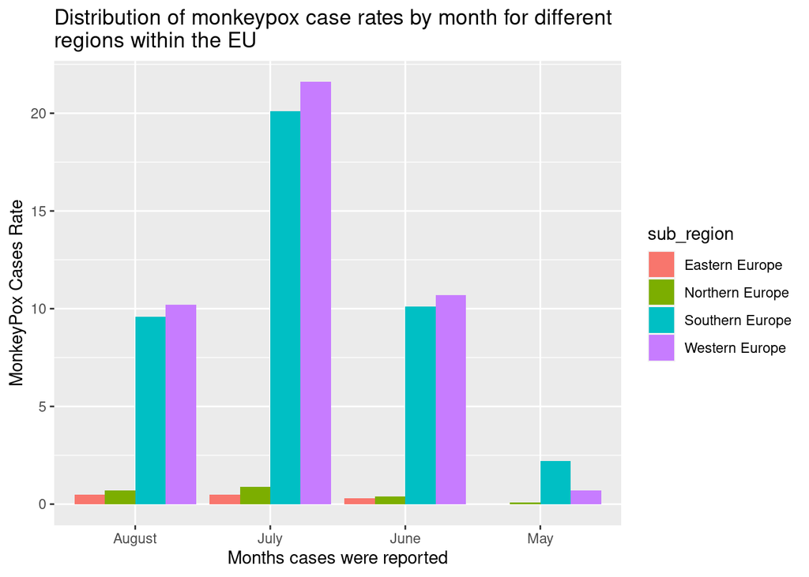

**Discussion**

Based on our investigation, we suggest an increase in surveillance in Western and Southern Europe as they need more support in dealing with an outbreak in monkeypox cases which means that the department of health in Europe should implement the strategies aimed at minimizing the infection of Monkeypox. July experience a peak of reported cases, which suggests that during hot seasons the cases increases compared to cold seasons, the department of health can allocate the funds meant for assistance of monkeypox during hot seasons.